# Macau Tourist Number Prediction 201506

小鑫

2015年7月21日

# 1 总体情况

## 1.1 关键方法和结果

1. 采用了四种预测方式，均值1585430：

   ＋ 基于Y2Y 增长额线性回归的预测【NEW】：1633552

   ＋ 基于Y2Y 增长额历史均值稳定性的预测：1548249

   ＋ 基于M2M月度一阶差分预测：1552438

   ＋ 基于百度指数的线性回归预测：1607482
2. 请交叉验证
3. 自动报告文档，格式还不完善。

## 1.2 关键参数

1. 仿真输入：澳门赌场（上个月）的百度指数（中度相关）或者holiday哑变量（短期强相关）
2. 学习时间：2015年2月－5月（短期回归）
3. 仿真结果：1585430

## 1.3 几点说明

1. 澳门预测难度比较大，因为相关性好的百度指数不太好找
2. 澳门的特点是季节性比较强，和假期相关性高，如何给每个假期（寒暑假）配置权重是后续的研究重点
3. 澳门每年二三季度的变化不大，但是一四季度不太好预测。一季度因为有新年，而2014年四季度变化比较剧烈。
4. 香港，和澳门相关性大，但是香港旅游官方数据在下个月月底出，晚于澳门（每个月23/24日出），很可惜，但是可以用澳门数来预测香港。
5. 这样的预测真的很烧脑，很花时间，尤其是数据不够的时候。后续，还得集思广益，看看有什么相关的数据能用。

# 2 Overview

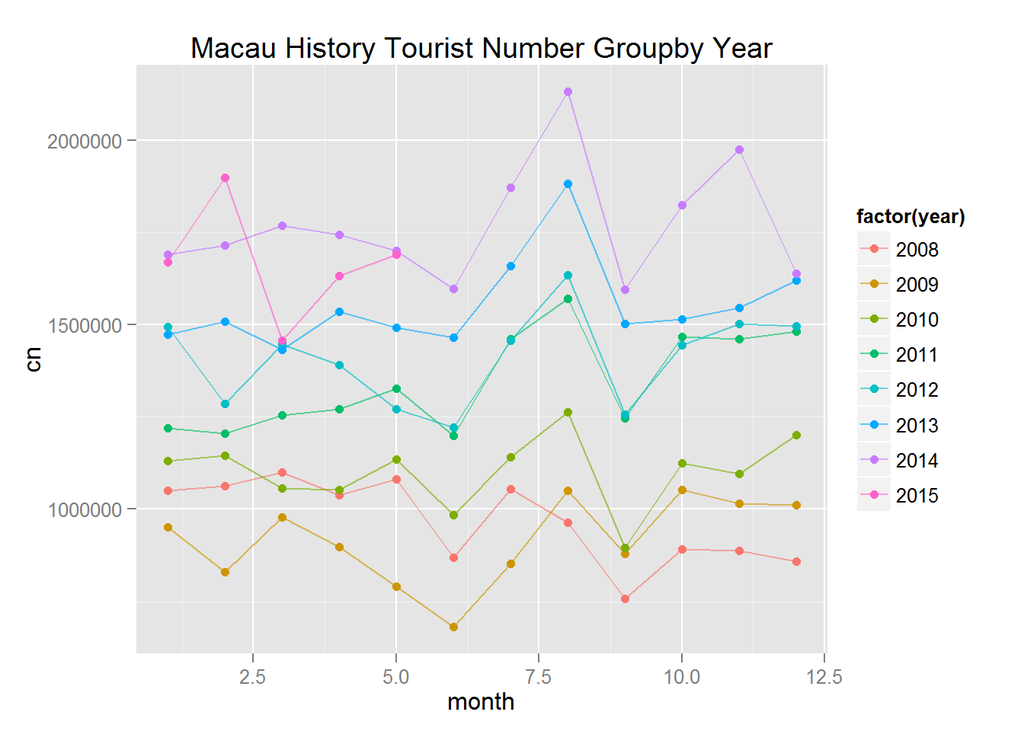

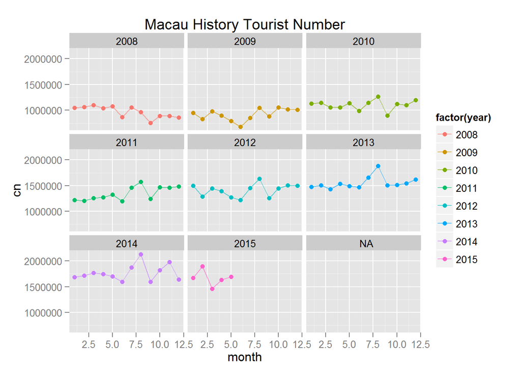

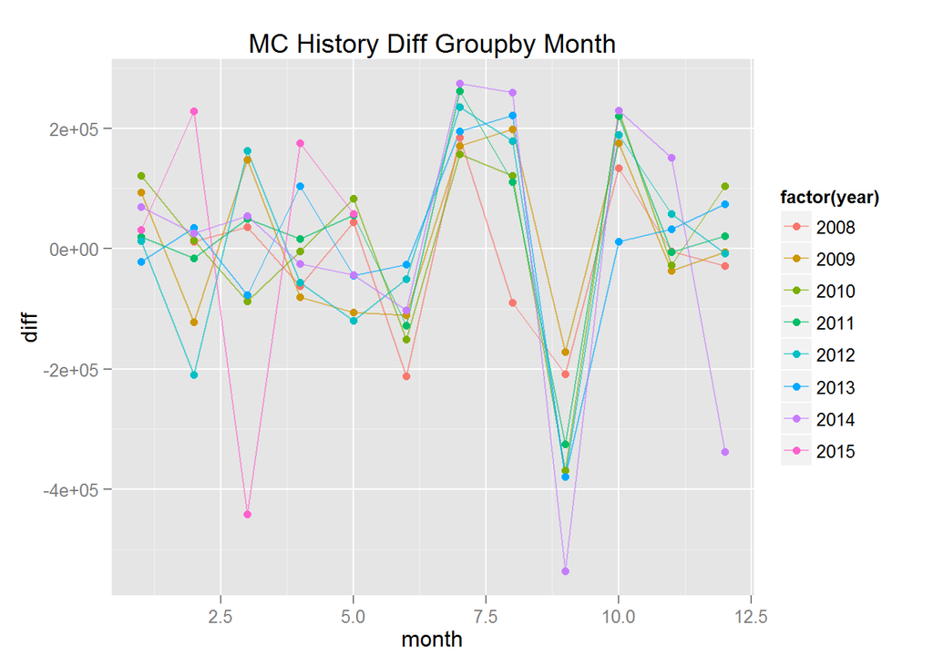

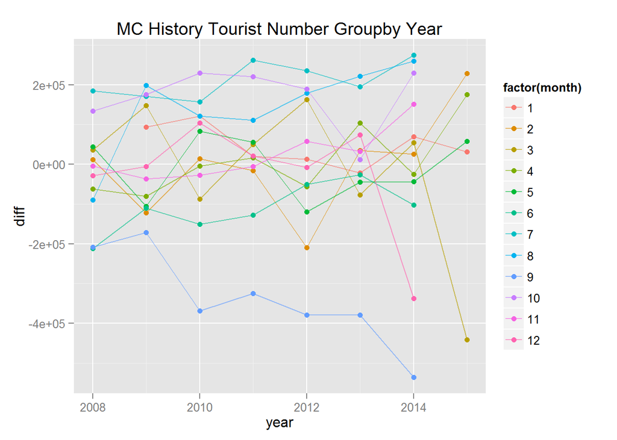

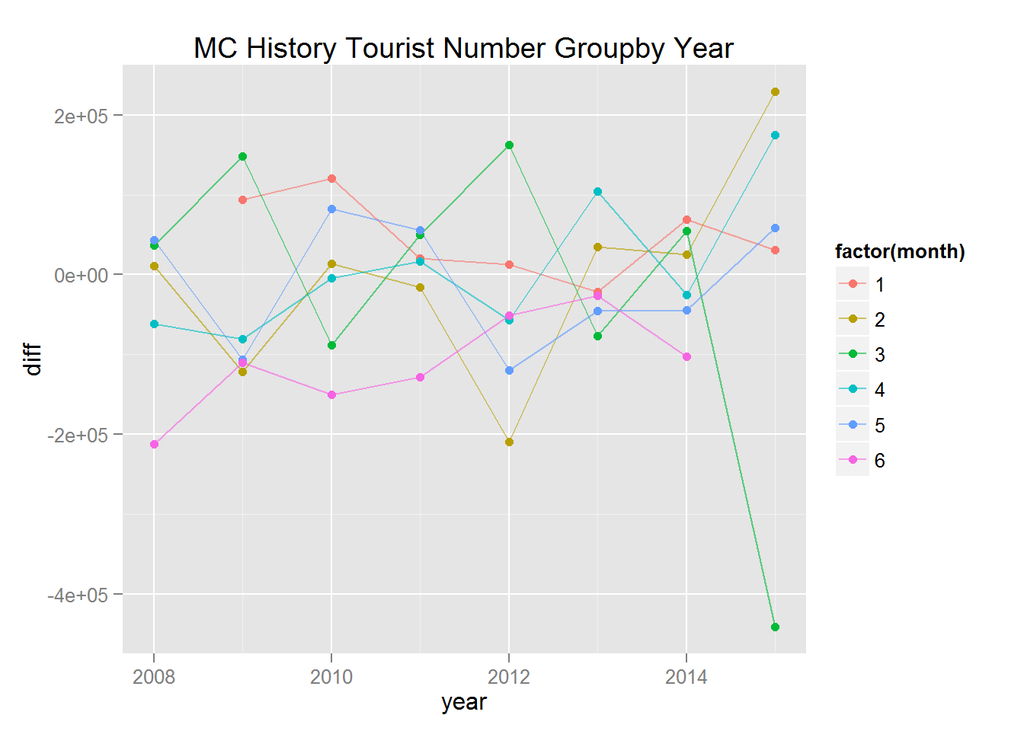

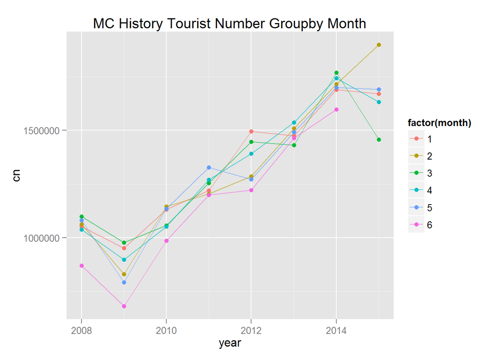

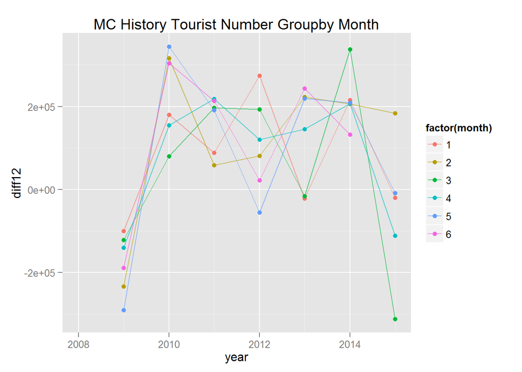

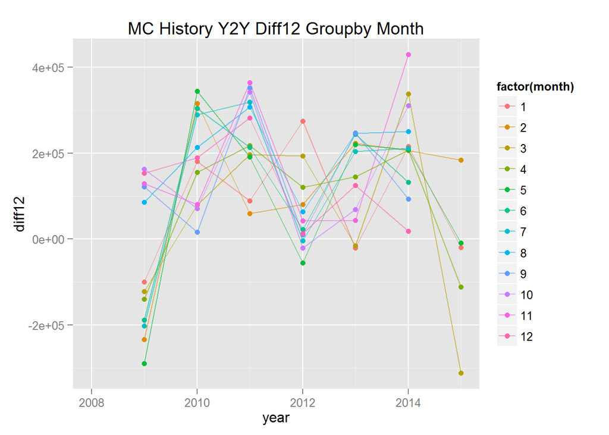

# 3 基于Y2Y 增长额线性回归预测：1633552

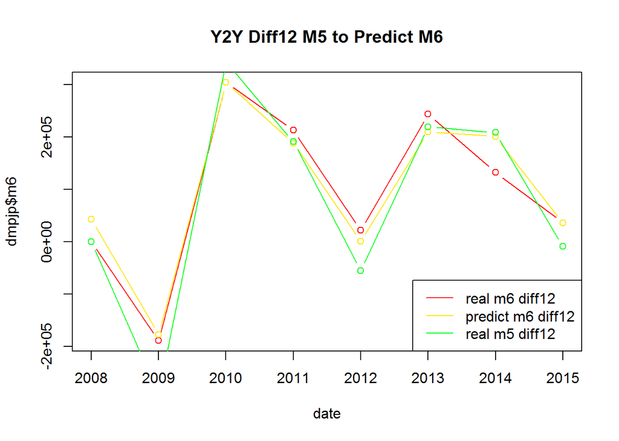

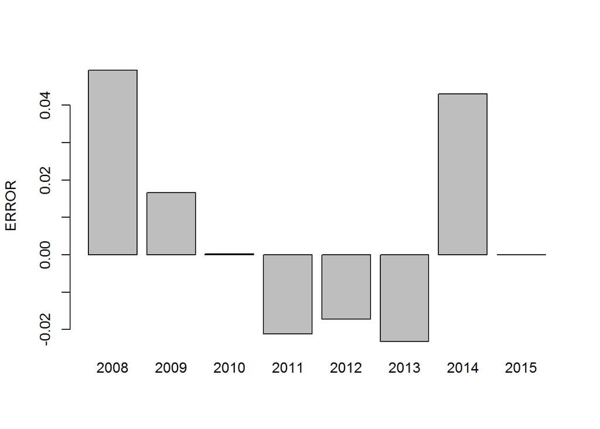

# 4 基于Y2Y 增长额稳定性预测：1548249

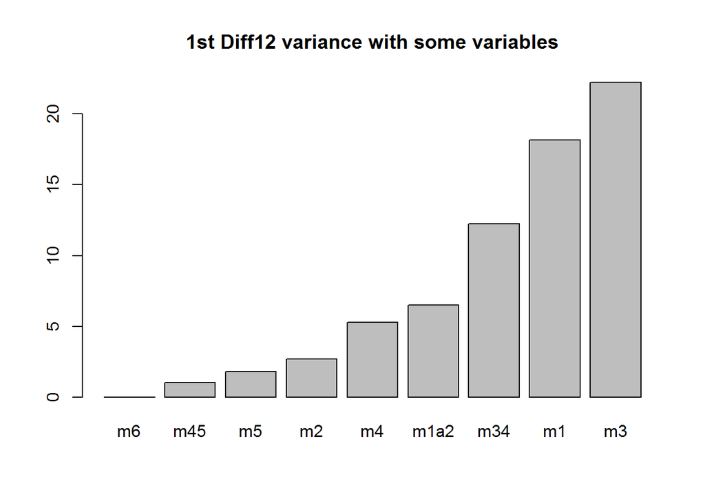

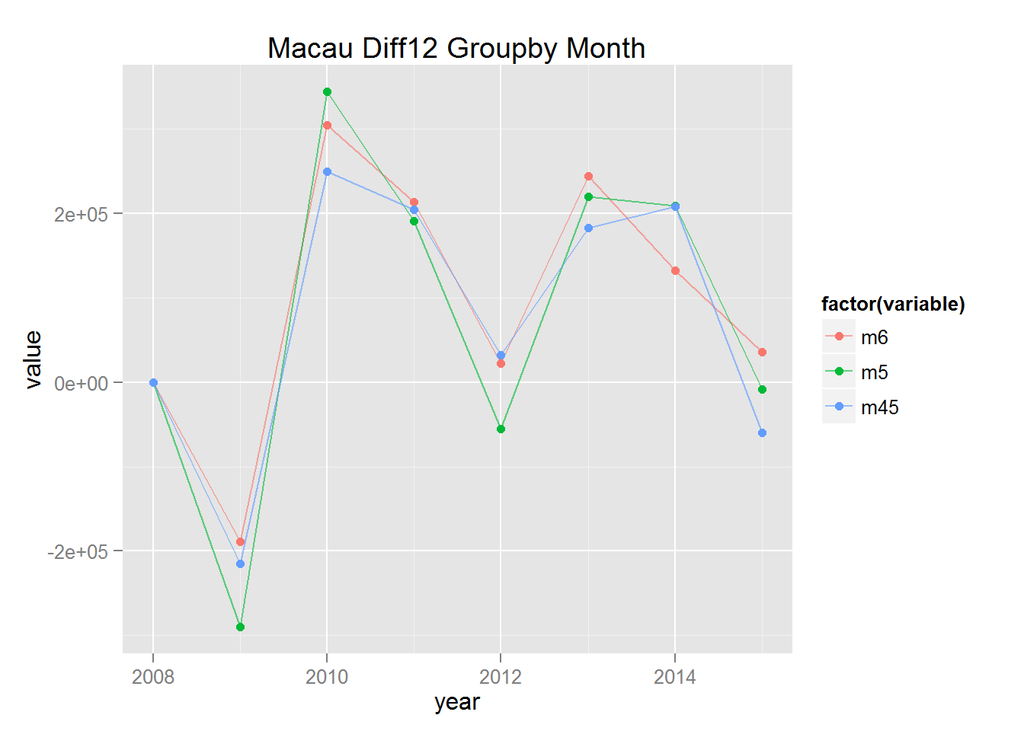

# 5 基于M2M月度一阶差分预测：1552438

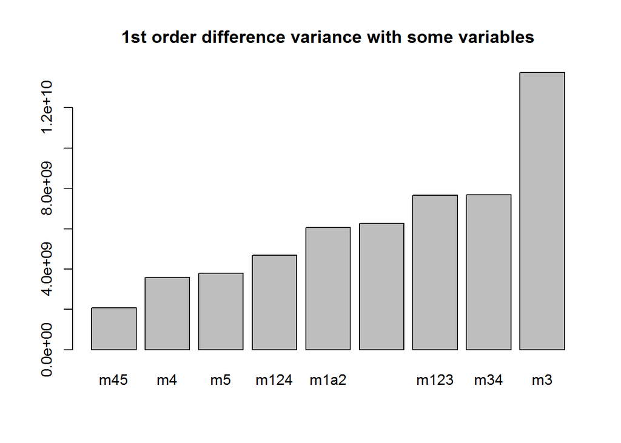

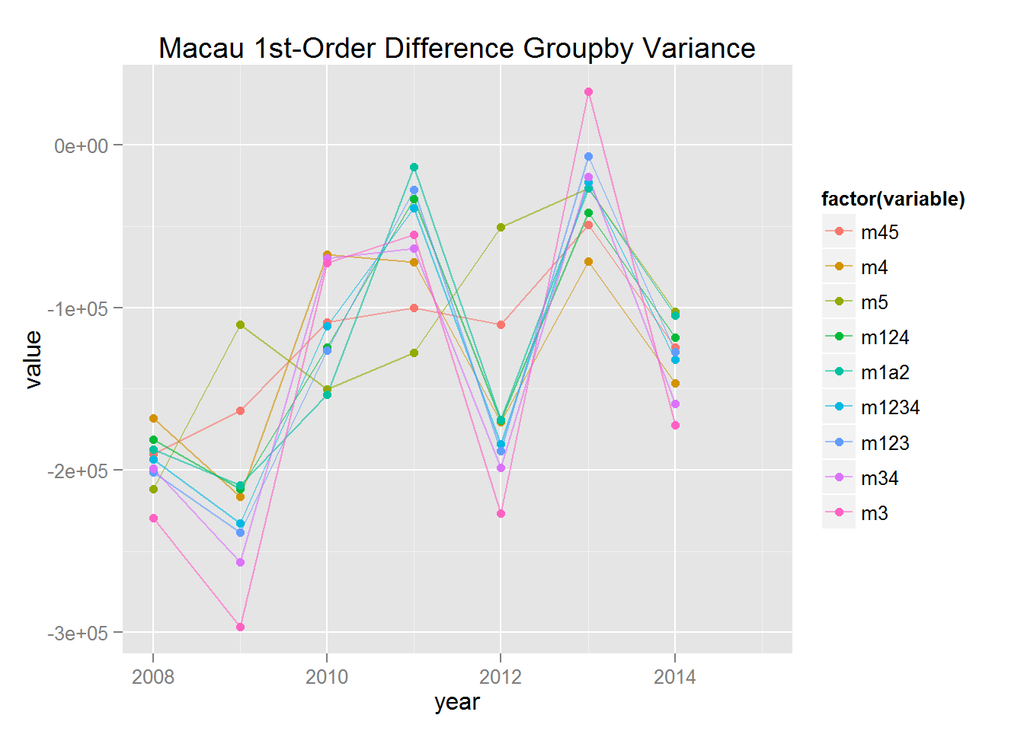

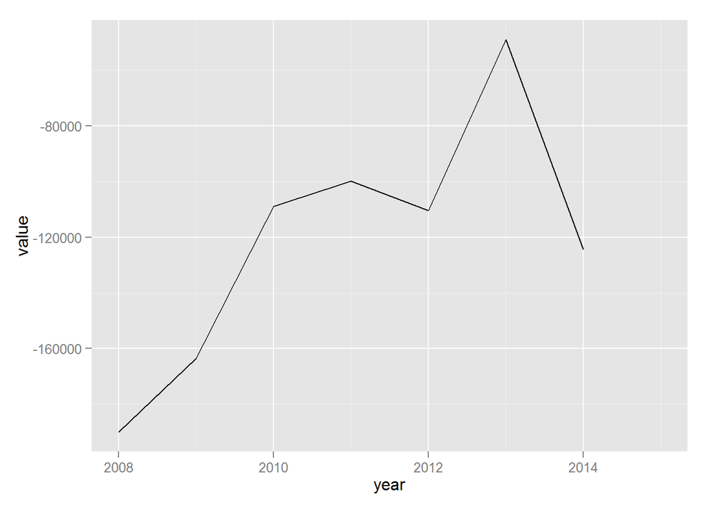

# 6 基于百度指数的线性回归预测：1607482

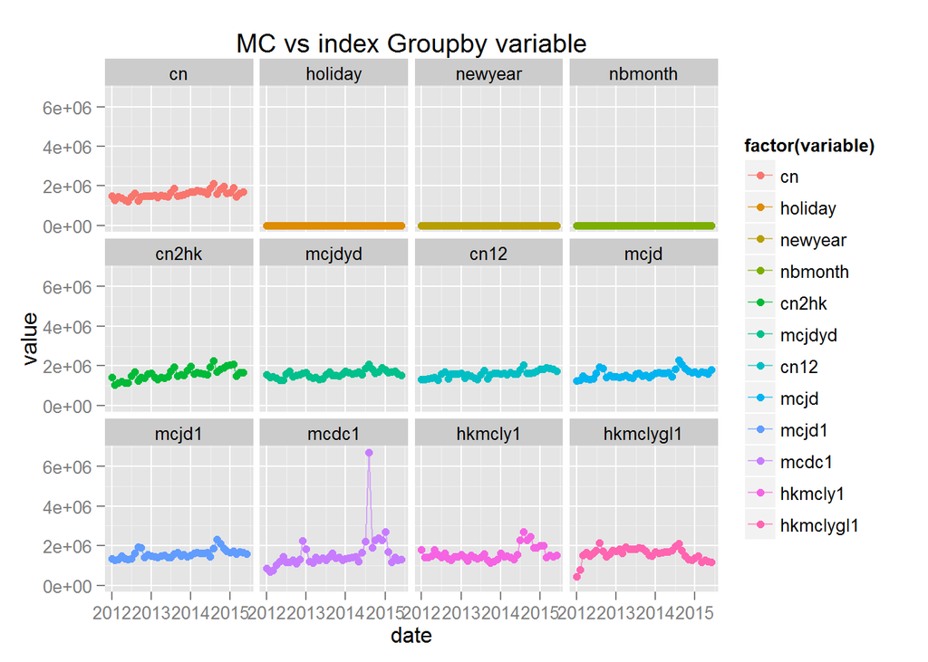

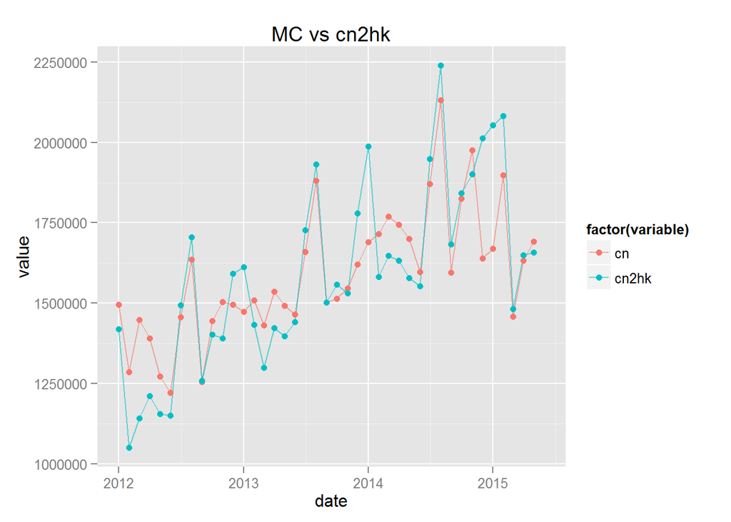

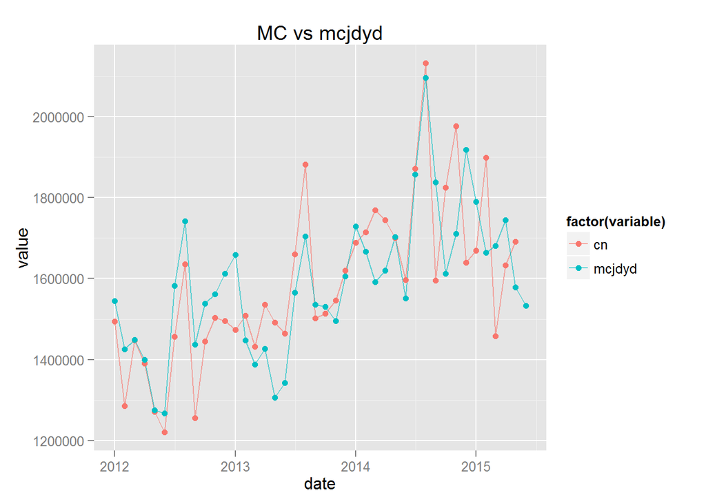

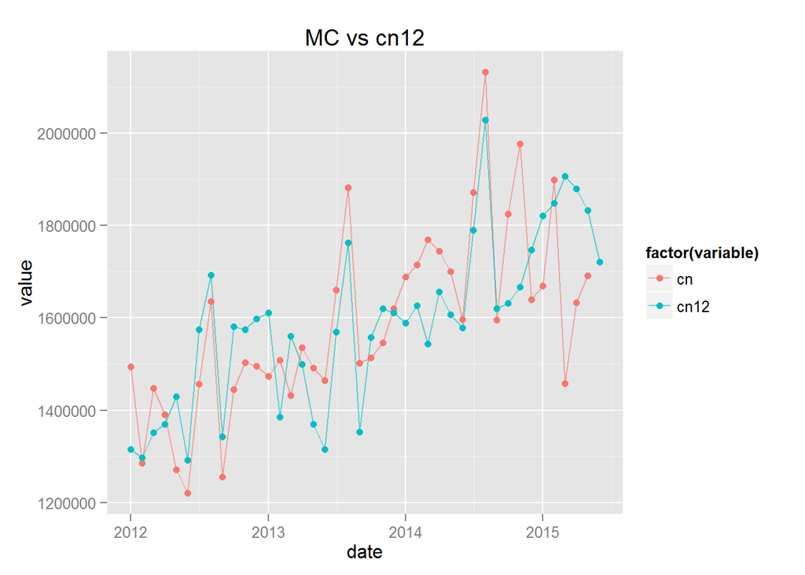

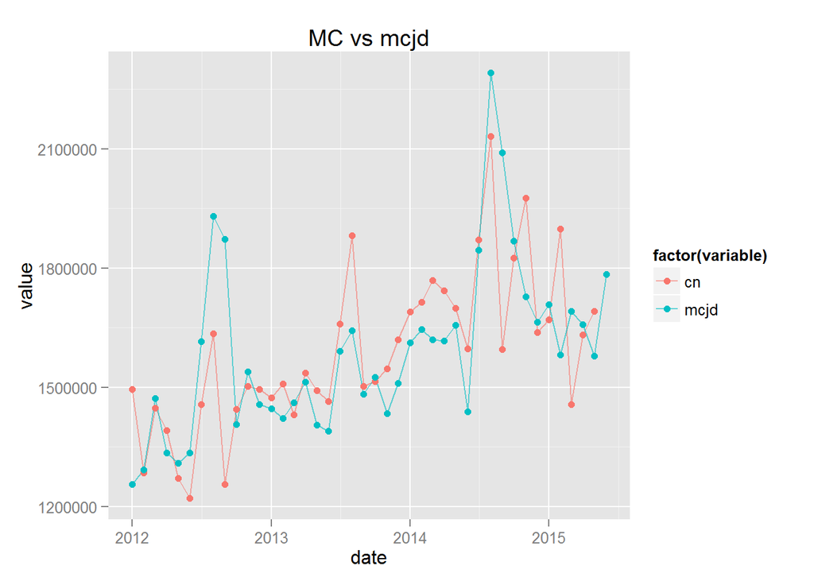

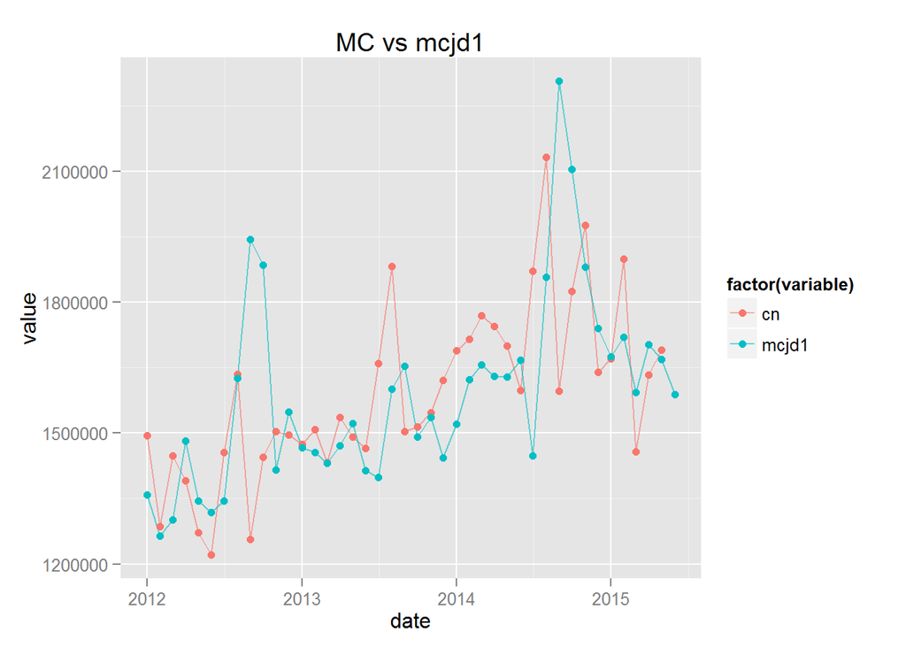

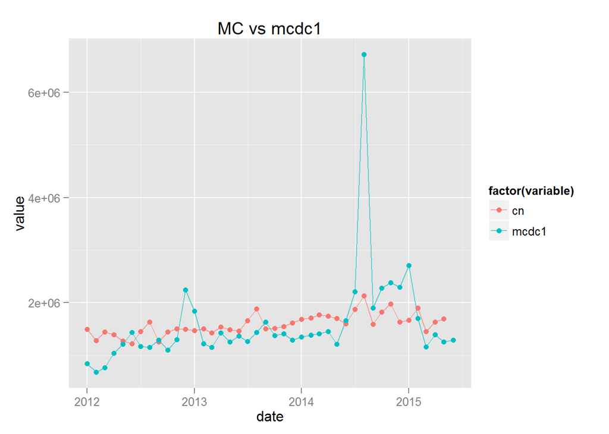

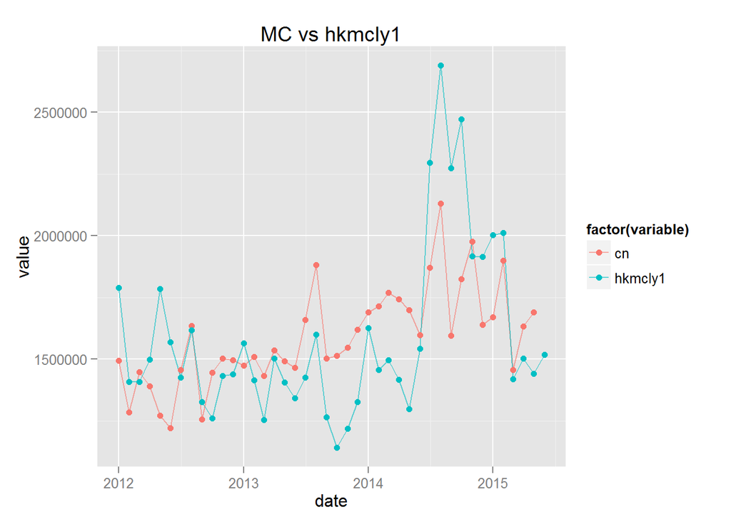

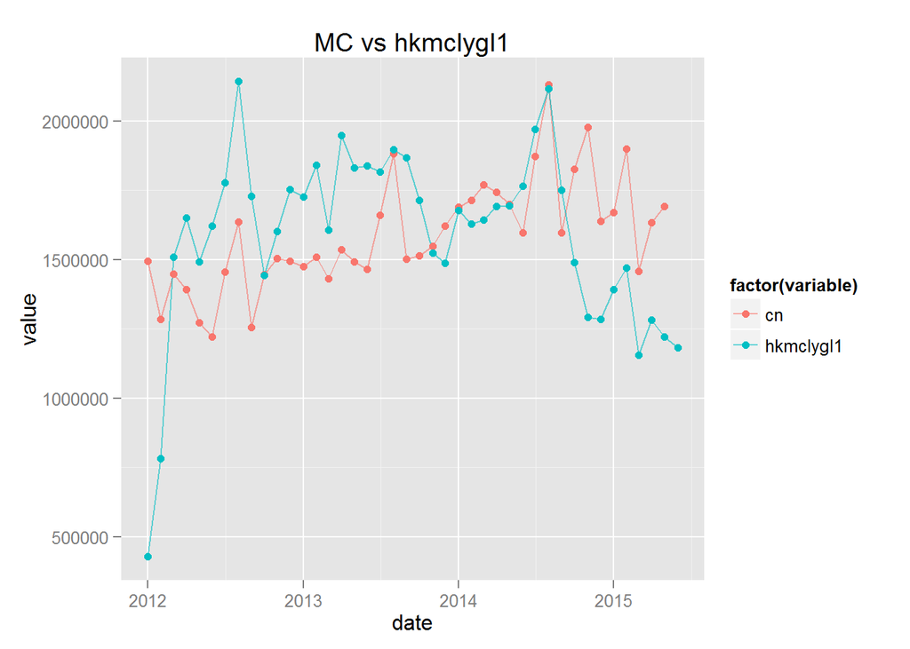

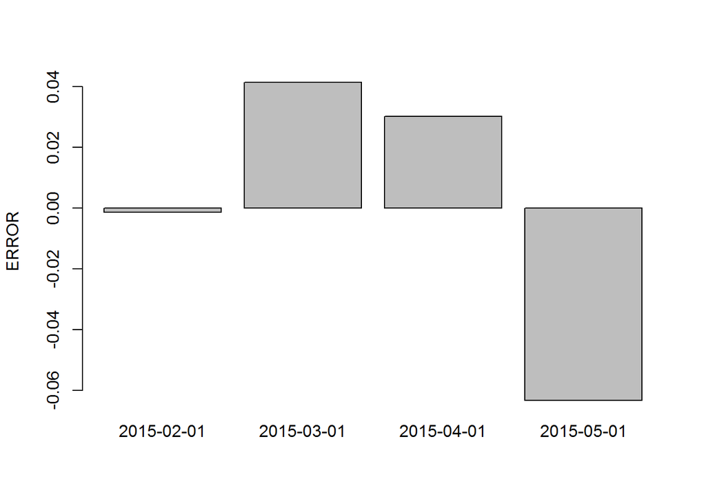

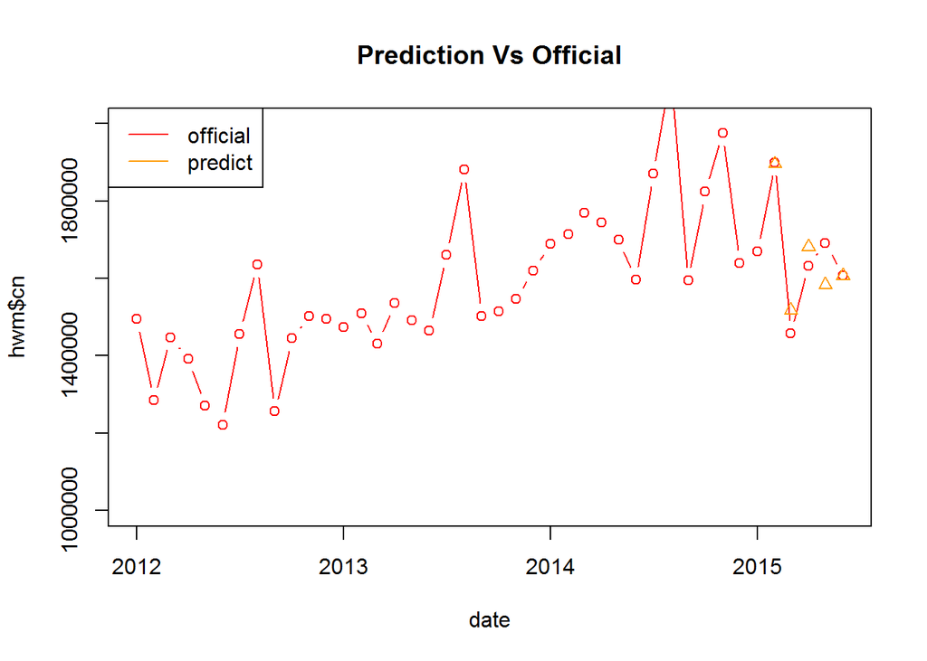

# 7 仿真结果

[output not shown]